# BRB-seq sample-identity check — best Skim-RTI / MolB-RTI match per BrB-RTI sample

Author

Fausto Rodríguez-Zapata

Published

June 26, 2026

**Repo:** sawers-rellan-labs/zealtiger

Mislabeling check for the **BRB-seq** run. For every BrB-RTI sample we search the **full Skim-RTI pool** (1,393 SNP50K samples) and the **MolB-RTI** set (16 target- sequencing samples) for the best genotype match — the same donor-pattern comparison used for the `PN4_SID330` swap (`agent/find_pn4_sid330_match.R`, `agent/molb330_vs_skim322.png`). If a BrB sample’s donor pattern matches a **differently-named** sample better than its own label, that flags a likely swap.

**Metric.** Each call set is projected onto the common wideseq grid (9,157 sites); similarity is the **donor Jaccard** `J = |donor_a ∩ donor_b| / |donor_a ∪ donor_b|` (donor = state ∈ {het, hom-donor}), with marker-level concordance reported alongside. Jaccard keys on *where the introgressions are*, which is what identifies a line.

## Setup

```r
library(tidyverse); library(data.table); library(GenomicRanges); library(ggpubr)
pal <- c(REF = "gold", HET = "springgreen4", ALT = "purple4")

brb  <- read_csv(params$brb_calls,  show_col_types = FALSE)
skim <- read_csv(params$skim_calls, show_col_types = FALSE)
mb   <- read_csv(params$mb_calls,   show_col_types = FALSE)

cf   <- read_tsv(list.files(params$mb_counts, full.names = TRUE)[1],
                 col_names = c("chr_label","bp","rb","rc","ab","ac"), show_col_types = FALSE)
grid <- tibble(chr = as.integer(sub("chr","",cf$chr_label)), bp = cf$bp) %>%
  mutate(gi = row_number())

# project a (possibly multi-sample) segment table onto the grid -> matrix [n_grid x n_sample]
project_matrix <- function(seg) {
  sk  <- as.data.table(seg)[, .(name, chr = as.character(chr), start_bp, end_bp, state)]
  gdt <- as.data.table(grid)[, .(gi, chr = as.character(chr), start = bp, end = bp)]
  setkey(sk, chr, start_bp, end_bp)
  ov  <- foverlaps(gdt, sk, by.x = c("chr","start","end"),
                   by.y = c("chr","start_bp","end_bp"), type = "within", nomatch = NULL)
  nm  <- sort(unique(ov$name))
  m   <- matrix(NA_integer_, nrow = nrow(grid), ncol = length(nm), dimnames = list(NULL, nm))
  m[cbind(ov$gi, match(ov$name, nm))] <- ov$state
  m
}

M_brb  <- project_matrix(brb)
M_skim <- project_matrix(skim)
M_mb   <- project_matrix(mb)

# donor Jaccard / concordance of a query vector vs every column of M
jac_vec  <- function(q, M) apply(M, 2, function(v) {
  ok <- !is.na(q) & !is.na(v); a <- q[ok] > 0; b <- v[ok] > 0
  u <- sum(a | b); if (u == 0) 0 else sum(a & b) / u })
conc_vec <- function(q, M) apply(M, 2, function(v) {
  ok <- !is.na(q) & !is.na(v); if (!any(ok)) NA_real_ else mean(q[ok] == v[ok]) })

brb_samples <- colnames(M_brb)
cat(sprintf("BrB-RTI samples: %d | Skim-RTI pool: %d | MolB-RTI pool: %d | grid: %d sites\n",
            ncol(M_brb), ncol(M_skim), ncol(M_mb), nrow(grid)))
```

```
BrB-RTI samples: 8 | Skim-RTI pool: 1393 | MolB-RTI pool: 16 | grid: 9157 sites
```

## Best match per BrB sample

For each BrB-RTI sample, the top Skim-RTI and top MolB-RTI match by donor Jaccard, with the **own-label** sample’s rank and J in each pool. A flag is raised when the best match is **not** the own label (and clearly beats it).

```r
rank_pool <- function(q, M, self) {
  J <- jac_vec(q, M); C <- conc_vec(q, M)
  dt <- data.table(name = colnames(M), donorJ = J, concord = C,
                   cand_donor = colMeans(M > 0, na.rm = TRUE))[order(-donorJ)]
  dt[, rank := .I]
  best <- dt[1]
  own  <- if (self %in% dt$name) dt[name == self] else NULL
  list(dt = dt, best = best, own = own)
}

summ <- map_dfr(brb_samples, function(s) {
  q  <- M_brb[, s]
  rs <- rank_pool(q, M_skim, s)
  rm <- rank_pool(q, M_mb,   s)
  tibble(
    brb_sample      = s,
    brb_donor_frac  = mean(q > 0, na.rm = TRUE),
    skim_best       = rs$best$name,
    skim_best_J     = rs$best$donorJ,
    skim_own_rank   = if (is.null(rs$own)) NA_integer_ else rs$own$rank,
    skim_own_J      = if (is.null(rs$own)) NA_real_    else rs$own$donorJ,
    molb_best       = rm$best$name,
    molb_best_J     = rm$best$donorJ,
    molb_own_rank   = if (is.null(rm$own)) NA_integer_ else rm$own$rank,
    molb_own_J      = if (is.null(rm$own)) NA_real_    else rm$own$donorJ,
    skim_swap = !is.na(skim_own_rank) & skim_best != s & skim_best_J > 1.5 * pmax(skim_own_J, 1e-6),
    molb_swap = !is.na(molb_own_rank) & molb_best != s & molb_best_J > 1.5 * pmax(molb_own_J, 1e-6))
})
knitr::kable(summ, digits = 3,
             caption = "Top Skim-RTI / MolB-RTI match per BrB-RTI sample, vs own-label rank/J. *_swap = best match is not the own label and beats it >1.5×.")
```

Top Skim-RTI / MolB-RTI match per BrB-RTI sample, vs own-label rank/J. *_swap = best match is not the own label and beats it >1.5×.

| brb_sample | brb_donor_frac | skim_best | skim_best_J | skim_own_rank | skim_own_J | molb_best | molb_best_J | molb_own_rank | molb_own_J | skim_swap | molb_swap |
| --- | --- | --- | --- | --- | --- | --- | --- | --- | --- | --- | --- |
| PN4_SID290 | 0.087 | PN11_SID970 | 0.589 | 404 | 0.055 | PN6_SID507 | 0.247 | 5 | 0.056 | TRUE | TRUE |
| PN4_SID291 | 0.089 | PN8_SID737 | 0.728 | 1190 | 0.000 | PN12_SID1101 | 0.235 | 10 | 0.017 | TRUE | TRUE |
| PN4_SID293 | 0.110 | PN6_SID549 | 0.927 | 964 | 0.001 | PN6_SID492 | 0.379 | 7 | 0.042 | TRUE | TRUE |
| PN4_SID309 | 0.037 | PN3_SID218 | 0.734 | 1038 | 0.001 | PN4_SID293 | 0.111 | 10 | 0.049 | TRUE | TRUE |
| PN4_SID320 | 0.151 | PN3_SID272 | 0.980 | 8 | 0.407 | PN4_SID320 | 0.408 | 1 | 0.408 | TRUE | FALSE |
| PN4_SID326 | 0.096 | PN4_SID336 | 0.908 | NA | NA | PN4_SID359 | 0.145 | 11 | 0.038 | FALSE | TRUE |
| PN4_SID330 | 0.041 | PN7_SID650 | 0.590 | 195 | 0.079 | PN4_SID309 | 0.077 | 6 | 0.051 | TRUE | FALSE |
| PN4_SID359 | 0.117 | PN14_SID1325 | 0.809 | 815 | 0.008 | PN6_SID568 | 0.323 | 14 | 0.013 | TRUE | TRUE |

```r
# full rankings to disk for inspection
dir.create("agent", showWarnings = FALSE)
walk(brb_samples, function(s) {
  rs <- rank_pool(M_brb[, s], M_skim, s)$dt
  fwrite(rs, sprintf("agent/brb_%s_skim_match_ranking.csv", s))
})
```

## Accession cross-check — label vs BRB-metadata vs genotype match

Does the genotype-recovered identity match the **pedigree/accession** in `BRBseq_metadata.csv` (keyed by the SID number) rather than the `PN#_SID#` plate label (from `molbreeding_45k_sample_map.tsv`)? The skim pool’s accessions come from `data/rtiger_50K/expDesign_all.csv`.

```r
# normalize pedigrees: the MolBreeding map appends a trailing ".B" that the BRB
# metadata omits, so chop it uniformly before any comparison
chop_B <- function(x) sub("\\.B$", "", x)

ed   <- read_csv("data/rtiger_50K/expDesign_all.csv", show_col_types = FALSE) %>%
  select(name, skim_acc = donor)
meta <- read_csv("data/BRBseq_metadata.csv", show_col_types = FALSE) %>%
  transmute(sid = sample_id, metadata_acc = accession,
            metadata_pedigree = chop_B(genotype))
mol  <- read_tsv("data/molbreeding_45k_sample_map.tsv", show_col_types = FALSE) %>%
  transmute(name = sample_id, label_pedigree = chop_B(genotype),
            label_acc = sub("_.*", "", genotype))

acc <- summ %>%
  transmute(brb = brb_sample, skim_best, J = round(skim_best_J, 2)) %>%
  mutate(sid               = as.integer(sub(".*_SID", "", brb)),
         label_acc         = mol$label_acc[match(brb, mol$name)],
         label_pedigree    = mol$label_pedigree[match(brb, mol$name)],
         metadata_pedigree = meta$metadata_pedigree[match(sid, meta$sid)],
         metadata_acc      = meta$metadata_acc[match(sid, meta$sid)],
         match_acc         = ed$skim_acc[match(skim_best, ed$name)],
         metadata_eq_genotype = metadata_acc == match_acc,
         label_eq_genotype    = label_acc == match_acc) %>%
  select(brb, label_pedigree, metadata_pedigree, label_acc, metadata_acc,
         skim_best, match_acc, J, metadata_eq_genotype, label_eq_genotype)
knitr::kable(acc, caption = "Per BrB sample: plate-label pedigree/accession (molbreeding map) vs BRBseq_metadata pedigree/accession (.B normalized) vs the genotype-recovered (best skim match) accession.")
```

Per BrB sample: plate-label pedigree/accession (molbreeding map) vs BRBseq_metadata pedigree/accession (.B normalized) vs the genotype-recovered (best skim match) accession.

| brb | label_pedigree | metadata_pedigree | label_acc | metadata_acc | skim_best | match_acc | J | metadata_eq_genotype | label_eq_genotype |
| --- | --- | --- | --- | --- | --- | --- | --- | --- | --- |
| PN4_SID290 | Zx.0340_P2_P1_P1.1.1.1 | Zx.0560_P4_P3_P3.1.1.1 | Zx.0340 | Zx.0560 | PN11_SID970 | Zl.0040 | 0.59 | FALSE | FALSE |
| PN4_SID291 | Zx.0340_P2_P1_P1.2.1.1 | Zx.0570_P2_P1_P2.1.1.1 | Zx.0340 | Zx.0570 | PN8_SID737 | Zx.0570 | 0.73 | TRUE | FALSE |
| PN4_SID293 | Zx.0340_P2_P1_P2.2.1.1 | Zd.0030_P2_P3_P2.1.1.1 | Zx.0340 | Zd.0030 | PN6_SID549 | Zd.0030 | 0.93 | TRUE | FALSE |
| PN4_SID309 | Zx.0150_P2_P1_P1.1.1.1 | Zx.0370_P2_P5_P1.1.1.1 | Zx.0150 | Zx.0370 | PN3_SID218 | Zx.0040 | 0.73 | FALSE | FALSE |
| PN4_SID320 | Zx.0030_P2_P1_P2.1.1.1 | Zx.0160_P2_P3_P2.2.1.1 | Zx.0030 | Zx.0160 | PN3_SID272 | Zx.0160 | 0.98 | TRUE | FALSE |
| PN4_SID326 | B73-bulk | Zx.0020_P3_P3_P1.2.1.1 | B73-bulk | Zx.0020 | PN4_SID336 | Zx.0020 | 0.91 | TRUE | FALSE |
| PN4_SID330 | Zx.0030_P2_P4_P2.1.1.1 | Zx.0580_P2_P3_P3.1.1.1 | Zx.0030 | Zx.0580 | PN7_SID650 | Zx.0580 | 0.59 | TRUE | FALSE |
| PN4_SID359 | Zx.0560_P2_P3_P2.1.1.1 | Zd.0010_P3_P2_P3.1.1.1 | Zx.0560 | Zd.0010 | PN14_SID1325 | Zd.0010 | 0.81 | TRUE | FALSE |

```r
cat(sprintf("genotype match == BRBseq_metadata accession : %d / %d\n",
            sum(acc$metadata_eq_genotype, na.rm = TRUE), nrow(acc)))
```

```
genotype match == BRBseq_metadata accession : 6 / 8
```

```r
cat(sprintf("genotype match == plate-label accession      : %d / %d\n",
            sum(acc$label_eq_genotype, na.rm = TRUE), nrow(acc)))
```

```
genotype match == plate-label accession      : 0 / 8
```

```r
# is .B the whole story? compare the BRB-run pedigree set to the MolB/skim NIL set
brb_peds <- meta$metadata_pedigree[match(acc$sid, meta$sid)]
mol_peds <- mol$label_pedigree
cat(sprintf("\nBRB-run pedigrees ∩ MolB/skim NIL pedigrees (.B normalized): %d shared\n",
            length(intersect(brb_peds, mol_peds))))
```

```
BRB-run pedigrees ∩ MolB/skim NIL pedigrees (.B normalized): 0 shared
```

Pedigrees were normalized by chopping the trailing `.B` that the MolBreeding map appends but the BRB metadata omits. That formatting difference is *not* the cause: even after normalizing, the BRB-run pedigrees share **zero** exact strings with the MolB/skim PN4 NIL set — the BRB run sequenced a **different panel of NILs**, so this is genuine mislabeling, not a string-formatting artifact.

## Sample-by-sample painting

For each BrB-RTI sample (top lane), the **best Skim-RTI match** and **best MolB-RTI match**, plus the **own-label** Skim-RTI and MolB-RTI lanes for contrast. When the best match equals the own label the lane is annotated `(= own label)`.

```r
lane <- function(seg, nm, lab) {
  d <- seg %>% filter(name == nm)
  if (!nrow(d)) return(NULL)
  d %>% transmute(chr, start_bp, end_bp,
                  state = factor(state, 0:2, c("REF","HET","ALT")), lane = lab)
}

for (s in brb_samples) {
  sk_best <- summ$skim_best[summ$brb_sample == s]; sk_bestJ <- summ$skim_best_J[summ$brb_sample == s]
  mb_best <- summ$molb_best[summ$brb_sample == s]; mb_bestJ <- summ$molb_best_J[summ$brb_sample == s]
  sk_ownJ <- summ$skim_own_J[summ$brb_sample == s]; mb_ownJ <- summ$molb_own_J[summ$brb_sample == s]

  lanes <- bind_rows(
    lane(brb,  s,       sprintf("BrB-RTI  %s  (query)", s)),
    lane(skim, sk_best, sprintf("Skim-RTI  %s  (best J=%.2f)%s",
                                sk_best, sk_bestJ, if (sk_best == s) "  = own label" else "")),
    if (sk_best != s) lane(skim, s, sprintf("Skim-RTI  %s  (own label, J=%.2f)", s, sk_ownJ)),
    lane(mb,   mb_best, sprintf("MolB-RTI  %s  (best J=%.2f)%s",
                                mb_best, mb_bestJ, if (mb_best == s) "  = own label" else "")),
    if (mb_best != s) lane(mb, s, sprintf("MolB-RTI  %s  (own label, J=%.2f)", s, mb_ownJ)))

  lv <- unique(lanes$lane)                     # keep construction order, query on top
  lanes <- lanes %>% mutate(
    chr  = factor(chr, levels = 1:10, labels = paste0("chr", 1:10)),
    lane = factor(lane, levels = rev(lv)))      # rev so first lane sits on top in facet

  cat("\n\n### ", s, "\n\n")
  p <- ggplot(lanes, aes(xmin = start_bp/1e6, xmax = end_bp/1e6, ymin = 0, ymax = 1, fill = state)) +
    geom_rect() +
    facet_grid(lane ~ chr, scales = "free_x", space = "free_x", switch = "y") +
    scale_fill_manual(values = pal, drop = FALSE) +
    scale_x_continuous(labels = scales::unit_format(unit = "", scale = 1)) +
    labs(title = sprintf("BrB-RTI %s — best match vs own label", s),
         subtitle = "gold REF · green HET · purple ALT", x = "Position (Mb)", fill = "Genotype") +
    theme_classic2(base_size = 10) +
    theme(legend.position = "bottom",
          strip.background = element_blank(),
          strip.text.y.left = element_text(angle = 0, hjust = 1, size = 8),
          strip.text.x = element_text(size = 8),
          panel.spacing.x = unit(0.05, "lines"), panel.spacing.y = unit(0.15, "lines"),
          axis.text.y = element_blank(), axis.ticks.y = element_blank(),
          axis.title.y = element_blank(), axis.line.y = element_blank(),
          axis.text.x = element_text(size = 6))
  print(p)
  cat("\n\n")
}
```

### PN4_SID290

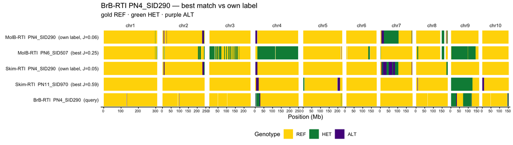

### PN4_SID291

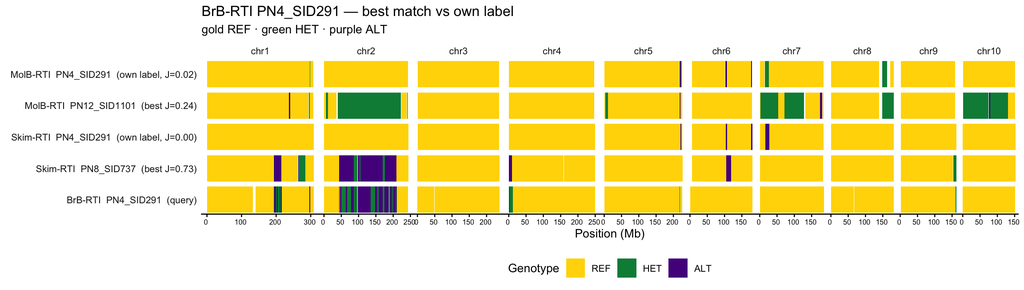

### PN4_SID293

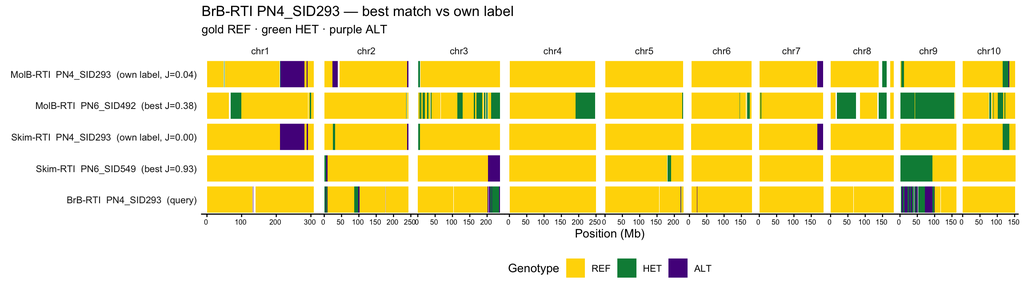

### PN4_SID309

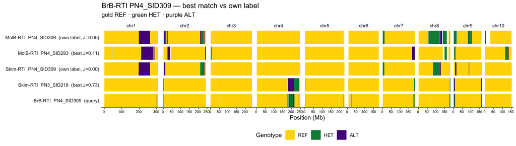

### PN4_SID320

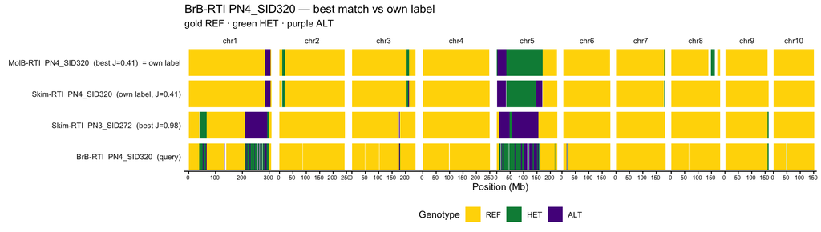

### PN4_SID326

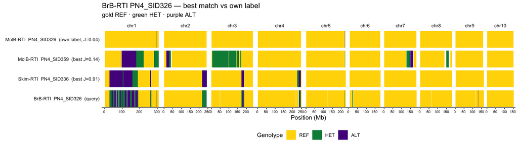

### PN4_SID330

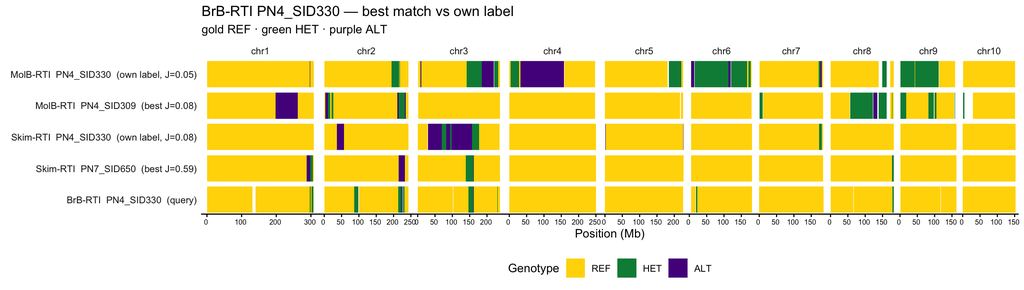

### PN4_SID359

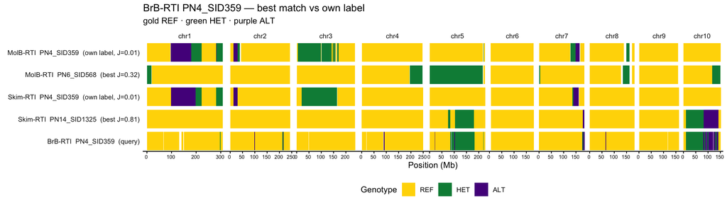

## Read

Compare each BrB-RTI query lane to its best-match and own-label lanes. A sample is a **clean label** when its best Skim-RTI and best MolB-RTI matches are its own name (top of the pool). A **suspected swap** is when the best match is a different sample that clearly outscores the own label — read off the `skim_swap` / `molb_swap` flags in the summary table and confirmed visually by donor-block overlap in the painting.

Crucially, each sample’s **own-label MolB-RTI and Skim-RTI lanes agree with each other** (DNA platforms), so the skim/target-sequencing labels are mutually consistent and it is the **BRB-seq labels that are off** — consistent with the independent clue that `BRBseq_metadata.csv` assigns different accessions to these SID numbers than `molbreeding_45k_sample_map.tsv`. The likely root cause is the BRB plate→well→SID naming, not the sequencing; the best-match column is a first estimate of each BrB tube’s true genotype identity. (`PN4_SID330`, the known MolB/skim swap, is the reference positive control.)